# Coding Assignment 3

Team 10

Due: 2021-12-08 23:59

```r
#Put any packages you need here
library(tidyverse) #parse file and read faster
library(readxl) #read excel file if necessary
library(car) #companion to applied regression - jic :)
library(gt)  #stylization of tables
library(gtsummary)  #stylization of statistics
library(scales) #create color palettes
```

```r
library(plotly) #enhanced graphical plotting
library(corrplot) #correlation plot
library(caTools) #Trying this one.  Let's see what happens
#notes on R
#Vector:  List of variables, smallest structure in R (numbers, arthimetic espressions, logical values or character strings)
#Data frame:  Most common way of storing dat in R.  List of elements.  Each element = columns and rows
#%>%:  Pipe Operator: Forwards information into next function
```

A Florida health insurance company wants to predict annual claims for individual clients. The company pulls a random sample of 50 customers. The owner wishes to charge an actuarially fair premium to ensure a normal rate of return. The owner collects all of their current customer’s health care expenses from the last year and compares them with what is known about each customer’s plan.

The data on the 50 customers in the sample is as follows:

- Charges: Total medical expenses for a particular insurance plan (in dollars)
- Age: Age of the primary beneficiary
- BMI: Primary beneficiary’s body mass index (kg/m2)
- Female: Primary beneficiary’s birth sex (0 = Male, 1 = Female)
- Children: Number of children covered by health insurance plan (includes other dependents as well)
- Smoker: Indicator if primary beneficiary is a smoker (0 = non-smoker, 1 = smoker)
- Cities: Dummy variables for each city with the default being Sanford

Answer the following questions using complete sentences and attach all output, plots, etc. within this report.

```r
#Ensure variable lable accuracy
Charges <- insurance[,1]
Age <- insurance[,2]
BMI <- insurance[,3]
Female <- insurance[,4]
Children <- insurance[,5]
Smoker <- insurance[,6]
WinterSprings <- insurance[,7]
WinterPark <- insurance[,8]
Oviedo <- insurance[,9]

summary(insurance)  #produce summaries of various model fitting functions
```

```
##     Charges           Age             BMI            Female        Children
##  Min.   : 1242   Min.   :18.00   Min.   :19.80   Min.   :0.00   Min.   :0.00
##  1st Qu.: 7899   1st Qu.:24.75   1st Qu.:26.51   1st Qu.:0.00   1st Qu.:0.00
##  Median :12360   Median :43.00   Median :30.90   Median :1.00   Median :1.00
##  Mean   :14337   Mean   :41.14   Mean   :30.37   Mean   :0.52   Mean   :1.24
##  3rd Qu.:16978   3rd Qu.:57.00   3rd Qu.:33.36   3rd Qu.:1.00   3rd Qu.:2.75
##  Max.   :46131   Max.   :64.00   Max.   :47.74   Max.   :1.00   Max.   :5.00
##      Smoker     WinterSprings   WinterPark       Oviedo
##  Min.   :0.00   Min.   :0.0   Min.   :0.00   Min.   :0.00
##  1st Qu.:0.00   1st Qu.:0.0   1st Qu.:0.00   1st Qu.:0.00
##  Median :0.00   Median :0.0   Median :0.00   Median :0.00
##  Mean   :0.24   Mean   :0.2   Mean   :0.32   Mean   :0.22
##  3rd Qu.:0.00   3rd Qu.:0.0   3rd Qu.:1.00   3rd Qu.:0.00
##  Max.   :1.00   Max.   :1.0   Max.   :1.00   Max.   :1.00
```

## Question 1

Randomly select three observations from the sample and exclude from all modeling (i.e. n=47). Provide the summary statistics (min, max, std, mean, median) of the quantitative variables for the 47 observations.

```r
set.seed(135791) #set seed therefore numbers will not continually vary forcing consistent analysis

index <- sample(seq_len(nrow(insurance)), size = 3) #remove three test observations

insuremost <- insurance[-index,] #47 observations model
insuretest <- insurance[index,] #3 observations test model

View(insuremost)
View(insuretest)
```

```r
#<h3 style="color:blue">Simple Summary - 47 Observations</h3>
#summary(insuremost) #min, max, mean, median
```

### Elaborate Summary - 47 Observations

```r
insuremost %>% #data then pipe operator
  tbl_summary(statistic = list(all_continuous() ~ c("{mean} ({sd})",
                                                    "{median} ({p25}, {p75})",
                                                    "{min}, {max}"),
                              all_categorical() ~ "{n} / {N} ({p}%)"),
              type = all_continuous() ~ "continuous2"
  )
```

| **Characteristic** | **N = 47**<sup>1</sup> |
| --- | --- |
| Charges |  |
| Mean (SD) | 14,688 (10,140) |
| Median (IQR) | 12,486 (8,070, 17,560) |
| Range | 1,712, 46,131 |
| Age |  |
| Mean (SD) | 41 (16) |
| Median (IQR) | 43 (26, 57) |
| Range | 18, 64 |
| BMI |  |
| Mean (SD) | 30.4 (5.8) |
| Median (IQR) | 30.8 (26.6, 33.2) |
| Range | 20.2, 47.7 |
| Female | 26 / 47 (55%) |
| Children |  |
| 0 | 19 / 47 (40%) |
| 1 | 14 / 47 (30%) |
| 2 | 2 / 47 (4.3%) |
| 3 | 9 / 47 (19%) |
| 4 | 1 / 47 (2.1%) |
| 5 | 2 / 47 (4.3%) |
| Smoker | 12 / 47 (26%) |
| WinterSprings | 10 / 47 (21%) |
| WinterPark | 15 / 47 (32%) |
| Oviedo | 9 / 47 (19%) |

<sup>1</sup> n / N (%)

### Notes/Observations

If we have observations that fall outside of our “Insure Most” data then there will be room for extrapolation error. We want to see our test values be between the Min and Max.

- Common sense states that a smoker is going to require more insurance than a non-smoker. Smokers usually are going to have to be charged more in insurance premiums.
- Age is a natural identifies of who will utilize more insurance. Younger people are generally healthier than older people and therefore pay less in insurance.
- BMI may or may not affect the amount of insurance a person would use and therefore need to be charged. This isn’t as intuitive as Age and Smoker.
- The curve is skewed to the right as the mean is about $2,000 larger than the median.
- The range is broad and it is likely that there are outliers in the data .

## Question 2

Provide the correlation between all quantitative variables

```r
#cor(insuremost)
```

### Correlation Significance - Visual Representation

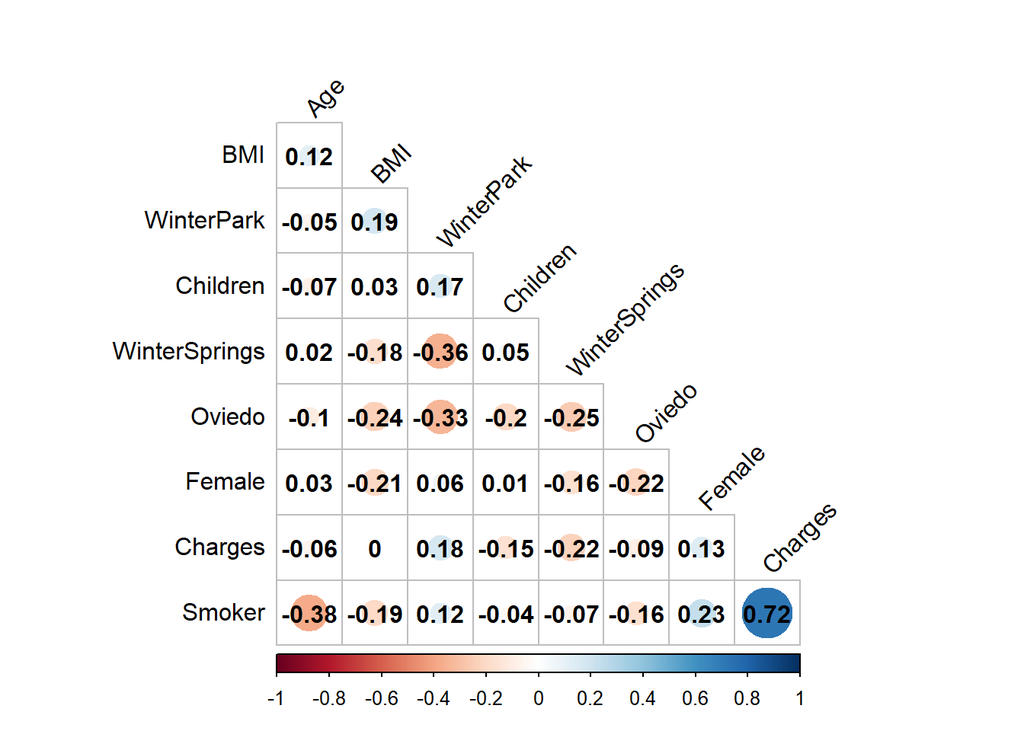

```r
corrplot(cor(insuremost),  #Correlation matrix
type = "lower",  #Correlation plot style (also "upper" and "full") - I can't read the lower very well
order = "hclust", #Request hierarchical clustering order - predominant ordering from top to bottom
tl.col = "black",
tl.srt = 45,
addCoef.col = "black",
diag = FALSE)
```

### Correlation Significance - Scatter Plot

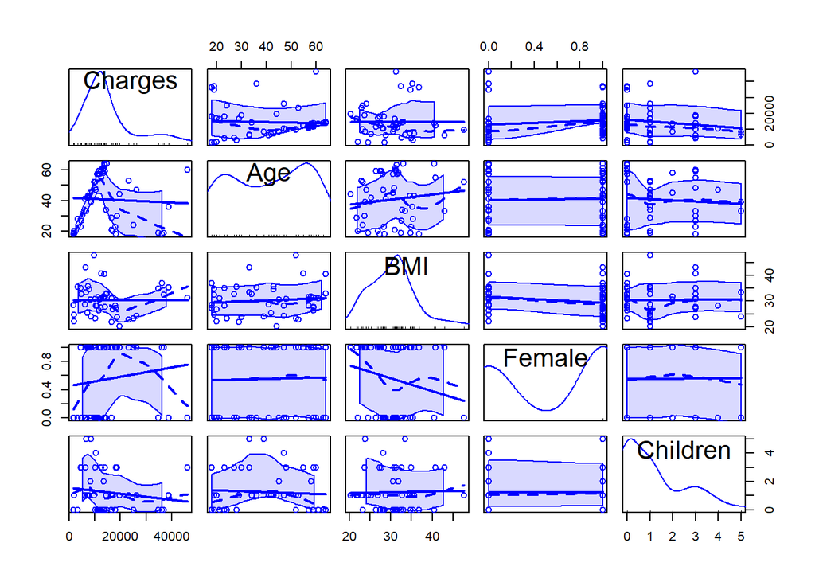

```r
scatterplotMatrix(insuremost[,1:5]) #errors from
```

## Question 3

Run a regression that includes all independent variables in the data table. Does the model above violate any of the Gauss-Markov assumptions? If so, what are they and what is the solution for correcting?

```r
#<h3 style="color:blue">Simple Regression Model</h3>
#Simple Regression

#summary(model)
```

### Elaborate Regression Model

```r
model <- lm(Charges ~., data = insuremost)
tbl_regression(model,
               estimate_fun =  ~style_sigfig(.x, digits = 4)) %>% as_gt() %>%
  gt::tab_source_note(gt::md(paste0("Adjusted R-Squared: ",round(summary(model)$adj.r.squared* 100,digits = 2),"%")))
```

| **Characteristic** | **Beta** | **95% CI**<sup>1</sup> | **p-value** |
| --- | --- | --- | --- |
| Age | 164.9 | 21.72, 308.1 | 0.025 |
| BMI | 185.4 | -223.2, 594.1 | 0.4 |
| Female | -1,164 | -5,772, 3,443 | 0.6 |
| Children | -681.7 | -2,147, 784.2 | 0.4 |
| Smoker | 19,358 | 13,963, 24,753 | <0.001 |
| WinterSprings | -2,820 | -9,202, 3,562 | 0.4 |
| WinterPark | 1,461 | -3,860, 6,783 | 0.6 |
| Oviedo | 1,528 | -5,476, 8,532 | 0.7 |

Adjusted R-Squared: 55.31%  
<sup>1</sup> CI = Confidence Interval

### Utilizing Plots to Evaluate Gauss-Markov Assumptions

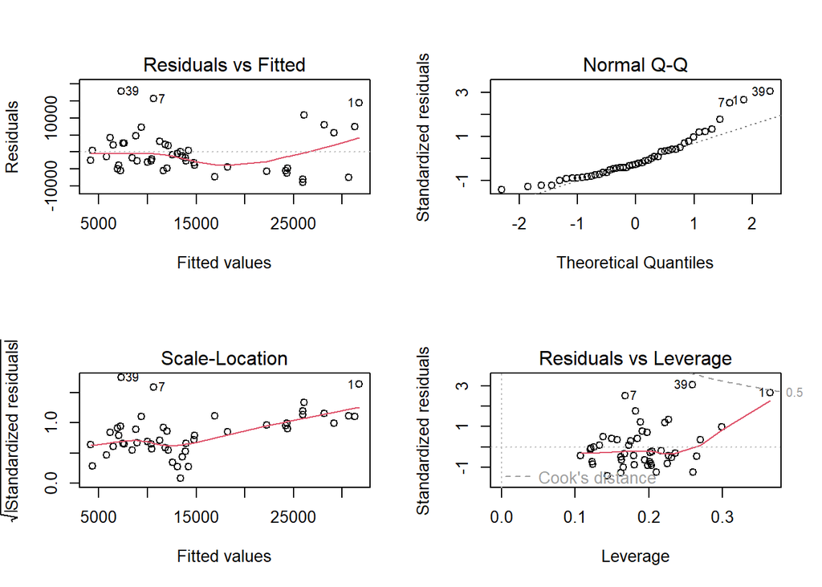

```r
par(mfrow=c(2,2))
plot(model)
```

## Question 4

Implement the solutions from question 3, such as data transformation, along with any other changes you wish. Use the sample data and run a new regression. How have the fit measures changed? How have the signs and significance of the coefficients changed?

### Data Transformation Utilizing Logs as Advised

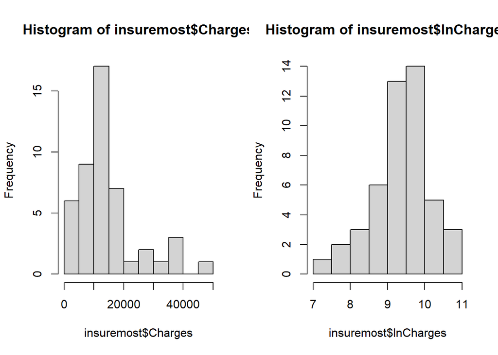

```r
par(mfrow=c(1,2))
hist(insuremost$Charges) #before
insuremost$lnCharges <- log(insuremost$Charges)
hist(insuremost$lnCharges) #after
```

### Log Data Scatterplots

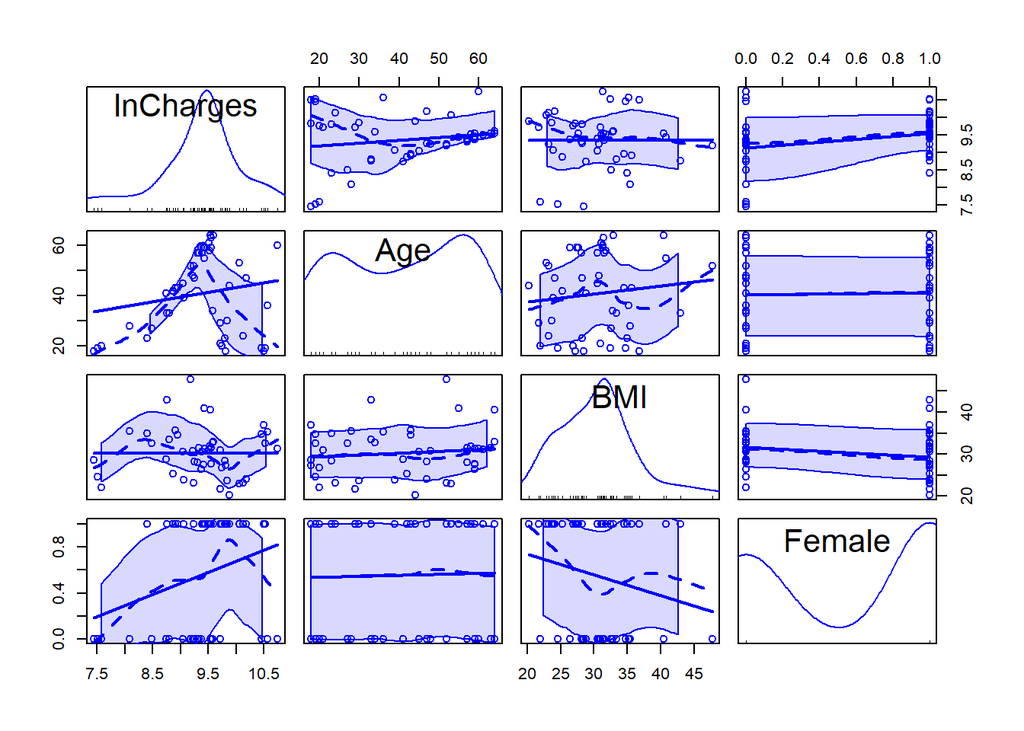

```r
scatterplotMatrix(insuremost[,c(10,2,3,4)]) # grabbing lnCharges
```

#### Evaluating Age with Data Models

```r
insuremost$lnAge <- log(insuremost$Age)
insuremost$sqAge <- log(insuremost$Age)
```

#### Age with Logarithmic Shape

```r
lnAge_Model <- lm(lnCharges ~., data = insuremost[,c(10,11,3:9)] ) #pulling only columns I want
summary(lnAge_Model)
```

```
##
## Call:
## lm(formula = lnCharges ~ ., data = insuremost[, c(10, 11, 3:9)])
##
## Residuals:
##      Min       1Q   Median       3Q      Max
## -0.83067 -0.23311 -0.03815  0.18604  1.21532
##
## Coefficients:
##               Estimate Std. Error t value Pr(>|t|)
## (Intercept)    5.70035    0.90797   6.278 2.37e-07 ***
## lnAge          0.80055    0.18708   4.279 0.000122 ***
## BMI            0.01163    0.01473   0.790 0.434667
## Female         0.14332    0.16624   0.862 0.394027
## Children      -0.06082    0.05250  -1.158 0.253902
## Smoker         1.31169    0.19532   6.716 5.98e-08 ***
## WinterSprings -0.15129    0.22982  -0.658 0.514314
## WinterPark     0.25677    0.19195   1.338 0.188950
## Oviedo         0.06387    0.25168   0.254 0.801030
## ---
## Signif. codes:  0 '***' 0.001 '**' 0.01 '*' 0.05 '.' 0.1 ' ' 1
##
## Residual standard error: 0.4947 on 38 degrees of freedom
## Multiple R-squared:  0.6416, Adjusted R-squared:  0.5661
## F-statistic: 8.503 on 8 and 38 DF,  p-value: 1.511e-06
```

```r
# or
tbl_regression(lnAge_Model,
               estimate_fun =  ~style_sigfig(.x, digits = 4)) %>% as_gt() %>%
  gt::tab_source_note(gt::md(paste0("Adjusted R-Squared: ",round(summary(lnAge_Model)$adj.r.squared* 100,digits = 2),"%")))
```

| **Characteristic** | **Beta** | **95% CI**<sup>1</sup> | **p-value** |
| --- | --- | --- | --- |
| lnAge | 0.8006 | 0.4218, 1.179 | <0.001 |
| BMI | 0.0116 | -0.0182, 0.0415 | 0.4 |
| Female | 0.1433 | -0.1932, 0.4798 | 0.4 |
| Children | -0.0608 | -0.1671, 0.0455 | 0.3 |
| Smoker | 1.312 | 0.9163, 1.707 | <0.001 |
| WinterSprings | -0.1513 | -0.6165, 0.3139 | 0.5 |
| WinterPark | 0.2568 | -0.1318, 0.6454 | 0.2 |
| Oviedo | 0.0639 | -0.4456, 0.5734 | 0.8 |

Adjusted R-Squared: 56.61%  
<sup>1</sup> CI = Confidence Interval

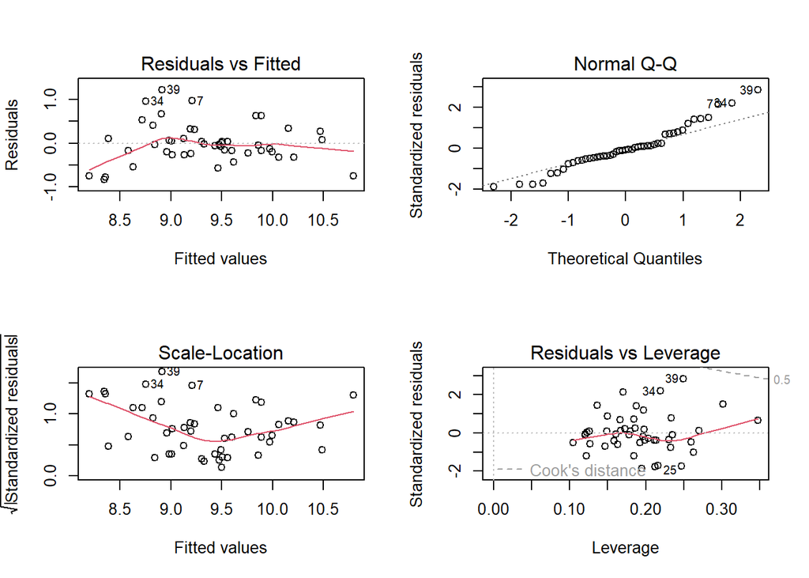

```r
par(mfrow=c(2,2))
plot(lnAge_Model)
```

### Transformation Solution Analysis

- Utilizing the log of Charges does make a significant difference in the shape of the distribution.
- There is nonlinearity between Charges and the other independent variables. It is difficult to determine the source of the nonlinearity.

  ```r
  QuadAge_Model <- lm(lnCharges ~., data = insuremost[,c(10,2:9,12)] ) #pulling only columns I want
  summary(QuadAge_Model)
  ```

  ```
  ##
  ## Call:
  ## lm(formula = lnCharges ~ ., data = insuremost[, c(10, 2:9, 12)])
  ##
  ## Residuals:
  ##     Min      1Q  Median      3Q     Max
  ## -0.8294 -0.2333 -0.0386  0.1865  1.2144
  ##
  ## Coefficients:
  ##                 Estimate Std. Error t value Pr(>|t|)
  ## (Intercept)    5.6601862  3.1328631   1.807   0.0789 .
  ## Age           -0.0004584  0.0341847  -0.013   0.9894
  ## BMI            0.0116315  0.0149279   0.779   0.4408
  ## Female         0.1431496  0.1689206   0.847   0.4022
  ## Children      -0.0611768  0.0595096  -1.028   0.3106
  ## Smoker         1.3117847  0.1980685   6.623 9.06e-08 ***
  ## WinterSprings -0.1516272  0.2342740  -0.647   0.5215
  ## WinterPark     0.2568701  0.1946653   1.320   0.1951
  ## Oviedo         0.0634383  0.2571177   0.247   0.8065
  ## sqAge          0.8169701  1.2389143   0.659   0.5137
  ## ---
  ## Signif. codes:  0 '***' 0.001 '**' 0.01 '*' 0.05 '.' 0.1 ' ' 1
  ##
  ## Residual standard error: 0.5013 on 37 degrees of freedom
  ## Multiple R-squared:  0.6416, Adjusted R-squared:  0.5544
  ## F-statistic:  7.36 on 9 and 37 DF,  p-value: 4.654e-06
  ```

  ```r
  # or
  tbl_regression(QuadAge_Model,
                 estimate_fun =  ~style_sigfig(.x, digits = 4)) %>% as_gt() %>%
    gt::tab_source_note(gt::md(paste0("Adjusted R-Squared: ",round(summary(QuadAge_Model)$adj.r.squared* 100,digits = 2),"%")))
  ```

  | **Characteristic** | **Beta** | **95% CI**<sup>1</sup> | **p-value** |
  | --- | --- | --- | --- |
  | Age | -0.0005 | -0.0697, 0.0688 | >0.9 |
  | BMI | 0.0116 | -0.0186, 0.0419 | 0.4 |
  | Female | 0.1431 | -0.1991, 0.4854 | 0.4 |
  | Children | -0.0612 | -0.1818, 0.0594 | 0.3 |
  | Smoker | 1.312 | 0.9105, 1.713 | <0.001 |
  | WinterSprings | -0.1516 | -0.6263, 0.3231 | 0.5 |
  | WinterPark | 0.2569 | -0.1376, 0.6513 | 0.2 |
  | Oviedo | 0.0634 | -0.4575, 0.5844 | 0.8 |
  | sqAge | 0.8170 | -1.693, 3.327 | 0.5 |

  Adjusted R-Squared: 55.44%  
  <sup>1</sup> CI = Confidence Interval

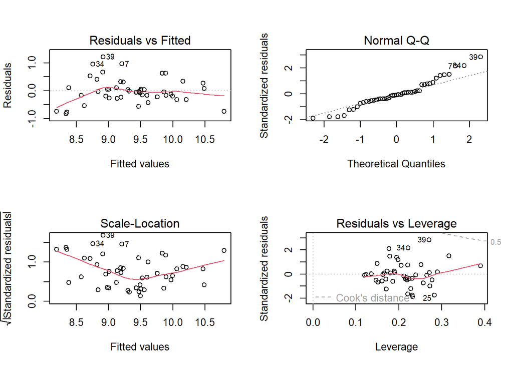

  ```r
  par(mfrow=c(2,2))
  plot(QuadAge_Model)
  ```

## Question 5

### Models

```r
insuretest$lnCharges <- log(insuretest$Charges)
insuretest$lnAge <- log(insuretest$Age)
insuretest$SqAge <- insuretest$Age^2

#insuretest$lnChildren <- log(insuretest$Children)

### ln_test_model_age: Charges with a logaritmic shape

#ln_test_model_age <- lm(lnCharges ~., data = insuretest[,c(10,2)] ) #pulling only columns I want
#summary(ln_test_model_age)
# or
#tbl_regression(model_1,
#               estimate_fun =  ~style_sigfig(.x, digits = 4)) %>% as_gt() %>%
#  gt::tab_source_note(gt::md(paste0("Adjusted R-Squared: ",round(summary(model_1)$adj.r.squared* 100,digits = 2),"%")))
```

[output not shown]